# Evaluating Solution Quality and Problem Difficulty using Code Metrics

2017-11-16

## Background Info

### Code-Compile-Evaluate Websites

- HackerRank
- CodeEval
- CodeChef
- CoderBytes
- TopCoder

[figure not shown]

## Problem

- Programming technologies pop up and disappear faster than textbooks can be printed
- Traditional teaching/testing methods being replaced by 'just in time' techniques
- Researchers and students are learning bad code style by only focusing on getting to the solution
- Interviewers are using online websites to judge code samples that don't consider many important aspects of programming.

## Significance

- Code-Compile-Evaluate loop websites have a large influence on the community
- Programming challenge websites could use this data to better score their puzzles
- HR-Level interviewers could better evaluate candidates

## Project Goals

- Identify which types of questions influence good/bad code style
- Discover the impact of good/bad code style on completion rates
- Make a conclusion about about the effects of factoring in code style as an evaluation measure in regards to accuracy.
- Future plans: Create a website that evaluates users solely based on how well they follow the style guide if their solution is correct

## Exploring the Dataset

time for some R fun

## Questions Data

```r
questions <- read.csv("data/questions.csv")
str(questions)
```

```
## 'data.frame':    1474 obs. of  13 variables:
##  $ QCode       : Factor w/ 1474 levels "A1","A2","A3",..: 1210 264 1195 594 179 699 793 1032 223 358 ...
##  $ Title       : Factor w/ 1456 levels "3-Palindromes",..: 706 337 1160 1120 484 701 778 600 172 1329 ...
##  $ link        : Factor w/ 1474 levels "/problems/A1",..: 1210 264 1195 594 179 699 793 1032 223 358 ...
##  $ level       : Factor w/ 5 levels "beginner","challenge",..: 5 3 5 1 1 5 3 3 5 5 ...
##  $ statement   : Factor w/ 1430 levels "\n\n                    function formatTime(ts) {\n                      now = new Date(ts);\n\n               "| __truncated__,..: 75 313 1077 6 986 1031 154 613 644 1364 ...
##  $ Author      : Factor w/ 128 levels "","ACRush","KADR",..: 47 23 97 113 11 65 119 112 39 28 ...
##  $ Tester      : Factor w/ 62 levels ""," Shilp Gupta.",..: 42 17 23 1 1 48 1 33 1 57 ...
##  $ Editorial   : Factor w/ 1227 levels "","http://discuss.codechef.com/problems/A3",..: 997 223 985 1 144 579 1 837 188 309 ...
##  $ Tags        : Factor w/ 1219 levels "['2d-fenwick', 'fenwick', 'sqrt-decomp', 'aug15', 'super-hard', 'segment-tree', 'mgch', 'range-tree']",..: 506 102 801 1162 59 712 464 1160 891 1054 ...
##  $ Date.Added  : Factor w/ 826 levels "","            1-01-2013</td>        <",..: 594 151 715 496 73 618 322 317 382 630 ...
##  $ Time.Limit  : Factor w/ 70 levels "","             - 1 sec</td>        <",..: 57 25 30 25 25 43 57 43 43 43 ...
##  $ Source.Limit: Factor w/ 11 levels "","            1000 Bytes</td>        <",..: 10 10 10 10 10 10 10 10 10 10 ...
##  $ Languages   : Factor w/ 53 levels "","            <td>ADA, ASM, BASH, BF, C, C99 strict, CAML, CLOJ, CLPS, CPP 4.3.2, CPP 4.9.2, CPP14, CS2, D, ERL, "| __truncated__,..: 5 5 2 2 2 5 5 5 5 5 ...
```

```r
head(questions, 2)
```

| QCode | Title | link | level | statement | Author | Tester | Editorial | Tags | Date.Added | Time.Limit | Source.Limit | Languages |
| --- | --- | --- | --- | --- | --- | --- | --- | --- | --- | --- | --- | --- |
| SEQUENCE | Integer Sequences | /problems/SEQUENCE | medium | \nAll submissions for this problem are available.\n\nFor a fixed integer n, let x1, x2, ..., x2n be a sequence that contains each of the 2n different n bit integers exactly once. To be precise, we say… | friggstad | pieguy | http://discuss.codechef.com/problems/SEQUENCE | ['friggstad', 'cook07', 'medium'] | 30-01-2011 < | 4 sec < | 50000 Bytes < | ADA, ASM, BASH, BF, C, C99 strict, CAML, CLOJ, CLPS, CPP 4.3.2, CPP 4.9.2, CPP14, CS2, D, ERL, FORT, FS, GO, HASK, ICK, ICON, JAVA, JS, LISP clisp, LISP sbcl, LUA, NEM, NICE, NODEJS, PAS fpc, PAS gpc,… |
| CHEFTEAM | Chef team | /problems/CHEFTEAM | easy | \nAll submissions for this problem are available.\nChef has N subordinates. In order to complete a very important order he will choose exactly K of them. He can't choose less than K since it will be n… | anton_lunyov | friggstad | http://discuss.codechef.com/problems/CHEFTEAM | ['anton_lunyov', 'cook06', 'easy'] | 14-01-2011 < | 1 sec < | 50000 Bytes < | ADA, ASM, BASH, BF, C, C99 strict, CAML, CLOJ, CLPS, CPP 4.3.2, CPP 4.9.2, CPP14, CS2, D, ERL, FORT, FS, GO, HASK, ICK, ICON, JAVA, JS, LISP clisp, LISP sbcl, LUA, NEM, NICE, NODEJS, PAS fpc, PAS gpc,… |

## Questions Data

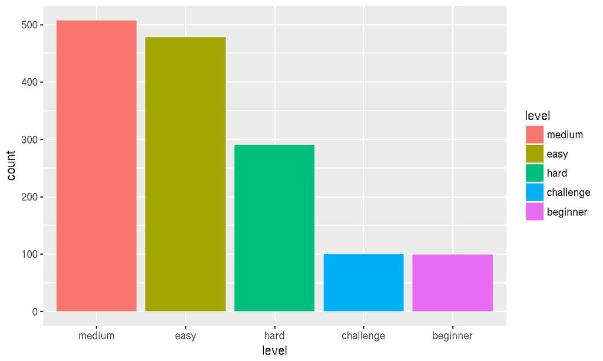

```r
questions$level = fct_infreq(questions$level)
qplot(level, fill = level, data = questions, geom = "bar")
```

## Solution Data

```r
solutions <- read.csv("data/solutions.csv")
str(solutions)
```

```
## 'data.frame':    637763 obs. of  9 variables:
##  $ QCode      : Factor w/ 545 levels "A1","A2","A3",..: 1 1 1 1 1 1 1 1 1 1 ...
##  $ SolutionID : Factor w/ 637763 levels "S100000","S10000000",..: 135461 136108 136111 136966 136967 138425 138719 138796 138857 138858 ...
##  $ timeago    : Factor w/ 510879 levels "01:00 AM 01/02/15",..: 271647 266727 268608 471576 472505 299275 218849 330027 14790 16466 ...
##  $ UserID     : Factor w/ 61245 levels "/users/12bit061",..: 23732 32343 32343 45595 45595 59637 44357 10057 38092 38092 ...
##  $ Status     : Factor w/ 15 levels "","accepted",..: 2 15 2 3 2 2 15 2 15 15 ...
##  $ TimeTaken  : Factor w/ 1501 levels "-","-1.00","0.00",..: 146 3 3 1 3 8 3 8 15 15 ...
##  $ MemTaken   : Factor w/ 3516 levels "-","0.1M","0.2M",..: 1711 1711 1711 1 1180 436 2171 436 1712 1712 ...
##  $ Language   : Factor w/ 50 levels "ADA","ASM","BASH",..: 5 5 5 9 9 28 9 28 11 11 ...
##  $ SolutionUrl: Factor w/ 637763 levels "","/viewplaintext/100000",..: 135462 136109 136112 136967 136968 138426 138720 138797 138858 138859 ...
```

```r
head(solutions, 2)
```

| QCode | SolutionID | timeago | UserID | Status | TimeTaken | MemTaken | Language | SolutionUrl |
| --- | --- | --- | --- | --- | --- | --- | --- | --- |
| A1 | S11986970 | 07:58 PM 31/10/16 | /users/ismail_2311 | accepted | 1.43 | 2M | C | /viewplaintext/11986970 |
| A1 | S11990433 | 07:51 PM 01/11/16 | /users/mohit_15 | wrong answer | 0.00 | 2M | C | /viewplaintext/11990433 |

## Solution Data

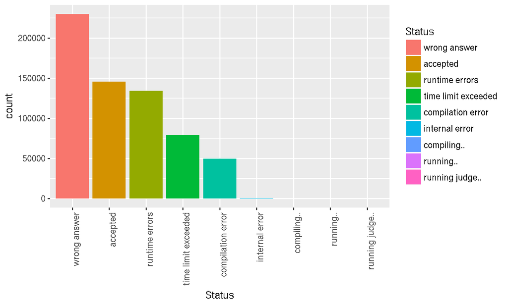

```r
runtimeErrors <- c("runtime error(SIGABRT)", "runtime error(SIGFPE)", "runtime error(OTHER)", "runtime error(NZEC)", "runtime error(SIGXFSZ)", "runtime error(SIGSEGV)", "")
solutions$Status <- solutions$Status %>% fct_collapse("runtime errors" = runtimeErrors)
solutions$Status = fct_infreq(solutions$Status)
qplot(Status, fill = Status, data = solutions, geom = "bar") + theme(axis.text.x = element_text(angle = 90, hjust = 1))
```

## Solution Data

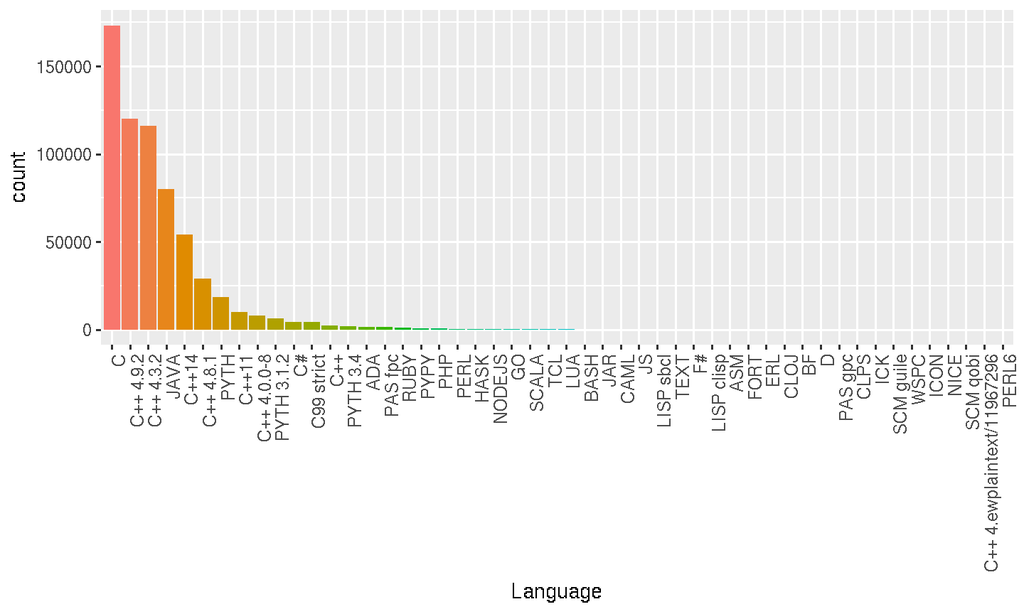

```r
solutions$Language = fct_infreq(solutions$Language)
qplot(Language, fill = Language, data = solutions, geom = "bar") + theme(axis.text.x = element_text(angle = 90, hjust = 1)) + guides(fill=FALSE)
```

## Code Data

```r
code <- read.csv("data/first.csv")
str(code)
```

```
## 'data.frame':    1 obs. of  2 variables:
##  $ SolutionID: Factor w/ 1 level "S12111596": 1
##  $ Solutions : Factor w/ 1 level "\n    #include<iostream>\n    using namespace std;\n    int main()\n    {\n    int i,t,temp,k;\n    cin>>t;\n  "| __truncated__: 1
```

```r
head(code, 1)
```

| SolutionID | Solutions |
| --- | --- |
| S12111596 | \n #include\n using namespace std;\n int main()\n {\n int i,t,temp,k;\n cin>>t;\n while(t--)\n {\n cin>>k;\n int a[k];\n for(i=0;i>a[i];\n temp=1-a[0];\n for(i=1;i<k;i++)\n {\n temp=2*temp;\n temp=tem… |

## Plan for Analysis

## Feature Creation

- Link 3 Datasets together (Question/Solution/Code)
- Process code samples into a value that accurately represents it's quality
- Only 3 major languages
- May need to separate dataset into languages to get fair comparison
- Process the question statement using NLP into a value that represents difficulty.
- Develop categories of questions using NLP library

## Planned Analysis

### Classifier for acceptance

- Create a model using logistic regression on the generated code quality feature
- Use that as a classifier that will predict if a solution's "Status" (approved/declined)

### Visualizations

- Correlation matrix showing the correlation between solution features and generated code quality feature
- Scatterplot between NLP derived difficulty and CodeChef difficulty.

## Current Issues

```r
words <- Corpus(VectorSource(questions$statement))
toSpace <- content_transformer(function (x , pattern ) gsub(pattern, " ", x))
words <- tm_map(words, toSpace, "/")
words <- tm_map(words, toSpace, "@")
words <- tm_map(words, toSpace, "\\|")
words <- tm_map(words, content_transformer(tolower))
words <- tm_map(words, removeWords, stopwords("english"))
words <- tm_map(words, removeNumbers)
words <- tm_map(words, removePunctuation)
words <- tm_map(words, stripWhitespace)
words <- tm_map(words, stemDocument)
v <- sort(rowSums(as.matrix(TermDocumentMatrix(words))),decreasing=TRUE)
d <- data.frame(word = names(v),freq=v)
```

## QUESTIONS?

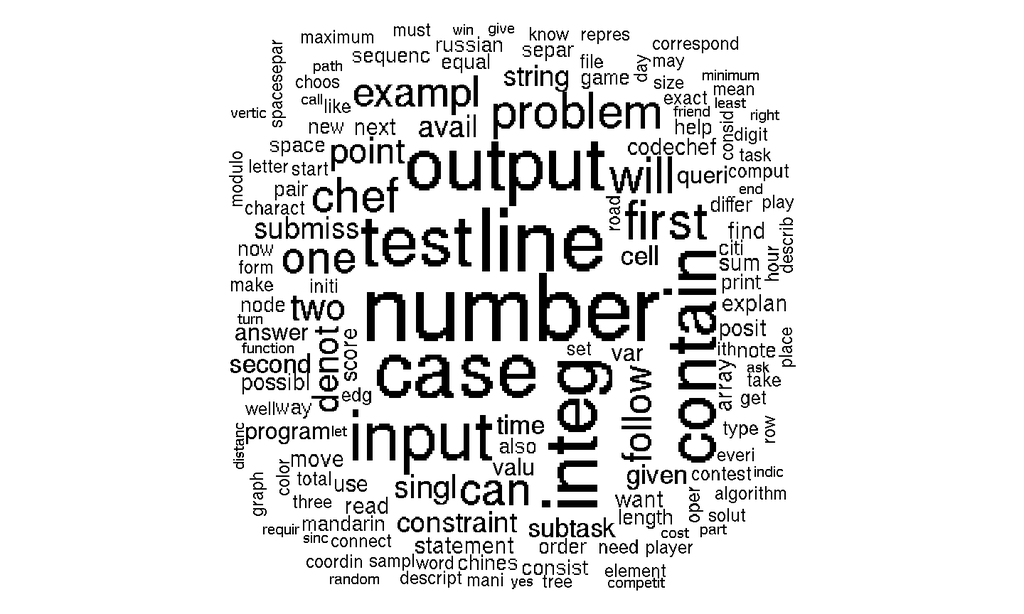

```r
wordcloud(words = d$word, freq = d$freq, min.freq = 1, max.words=150, random.order=FALSE)
```